# 10_correlations

Nick Schultz

3/12/2021

#### Read the data

```r
mh <- read_csv("MillerHadenData.csv")
```

#### Look at the data

```r
glimpse(mh)
```

```
## Rows: 25
## Columns: 5
## $ Participant <dbl> 1, 2, 3, 4, 5, 6, 7, 8, 9, 10, 11, 12, 13, 14, 15, 16, 17…
## $ Abil        <dbl> 61, 56, 45, 66, 49, 62, 61, 55, 62, 61, 51, 48, 50, 50, 6…
## $ IQ          <dbl> 107, 109, 81, 100, 92, 105, 92, 101, 118, 99, 104, 100, 9…
## $ Home        <dbl> 144, 123, 108, 155, 103, 161, 138, 119, 155, 121, 93, 127…
## $ TV          <dbl> 487, 608, 640, 493, 636, 407, 463, 717, 643, 674, 675, 59…
```

```r
head(mh)
```

```
## # A tibble: 6 x 5
##   Participant  Abil    IQ  Home    TV
##         <dbl> <dbl> <dbl> <dbl> <dbl>
## 1           1    61   107   144   487
## 2           2    56   109   123   608
## 3           3    45    81   108   640
## 4           4    66   100   155   493
## 5           5    49    92   103   636
## 6           6    62   105   161   407
```

```r
tail(mh)
```

```
## # A tibble: 6 x 5
##   Participant  Abil    IQ  Home    TV
##         <dbl> <dbl> <dbl> <dbl> <dbl>
## 1          20    54   104   102   678
## 2          21    52    98   124   564
## 3          22    48   117    87   787
## 4          23    61   100   141   582
## 5          24    54   101   117   647
## 6          25    48    94   111   448
```

```r
mh
```

```
## # A tibble: 25 x 5
##    Participant  Abil    IQ  Home    TV
##          <dbl> <dbl> <dbl> <dbl> <dbl>
##  1           1    61   107   144   487
##  2           2    56   109   123   608
##  3           3    45    81   108   640
##  4           4    66   100   155   493
##  5           5    49    92   103   636
##  6           6    62   105   161   407
##  7           7    61    92   138   463
##  8           8    55   101   119   717
##  9           9    62   118   155   643
## 10          10    61    99   121   674
## # … with 15 more rows
```

#### Assumptions:

- Is data interval/ratio/ordinal?
- Is there a data point for each participant on both variables?
- Is data normally distributed?
- Does the realationship appear linear?
- Does the spread have homoscedasticity?

Spearman correlation is non-parametric and can run with interval/ordinal/ratio data.

```r
is.na(mh)
```

```
##       Participant  Abil    IQ  Home    TV
##  [1,]       FALSE FALSE FALSE FALSE FALSE
##  [2,]       FALSE FALSE FALSE FALSE FALSE
##  [3,]       FALSE FALSE FALSE FALSE FALSE
##  [4,]       FALSE FALSE FALSE FALSE FALSE
##  [5,]       FALSE FALSE FALSE FALSE FALSE
##  [6,]       FALSE FALSE FALSE FALSE FALSE
##  [7,]       FALSE FALSE FALSE FALSE FALSE
##  [8,]       FALSE FALSE FALSE FALSE FALSE
##  [9,]       FALSE FALSE FALSE FALSE FALSE
## [10,]       FALSE FALSE FALSE FALSE FALSE
## [11,]       FALSE FALSE FALSE FALSE FALSE
## [12,]       FALSE FALSE FALSE FALSE FALSE
## [13,]       FALSE FALSE FALSE FALSE FALSE
## [14,]       FALSE FALSE FALSE FALSE FALSE
## [15,]       FALSE FALSE FALSE FALSE FALSE
## [16,]       FALSE FALSE FALSE FALSE FALSE
## [17,]       FALSE FALSE FALSE FALSE FALSE
## [18,]       FALSE FALSE FALSE FALSE FALSE
## [19,]       FALSE FALSE FALSE FALSE FALSE
## [20,]       FALSE FALSE FALSE FALSE FALSE
## [21,]       FALSE FALSE FALSE FALSE FALSE
## [22,]       FALSE FALSE FALSE FALSE FALSE
## [23,]       FALSE FALSE FALSE FALSE FALSE
## [24,]       FALSE FALSE FALSE FALSE FALSE
## [25,]       FALSE FALSE FALSE FALSE FALSE
```

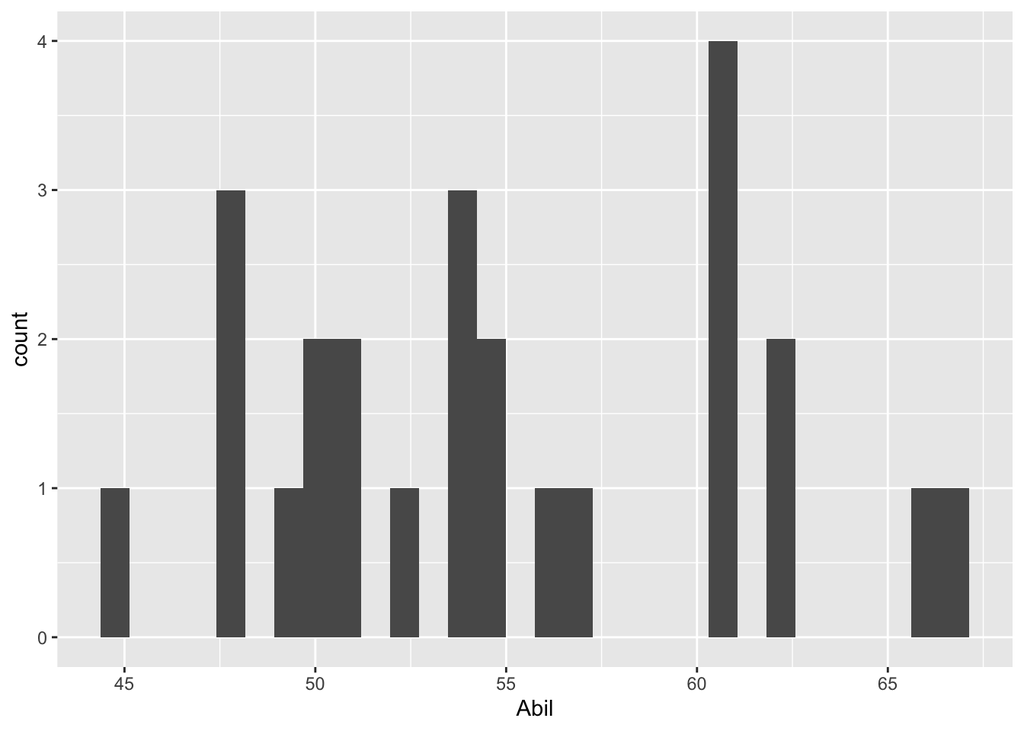

```r
ggplot(mh, aes(Abil)) +
  geom_histogram(bins = 30)
```

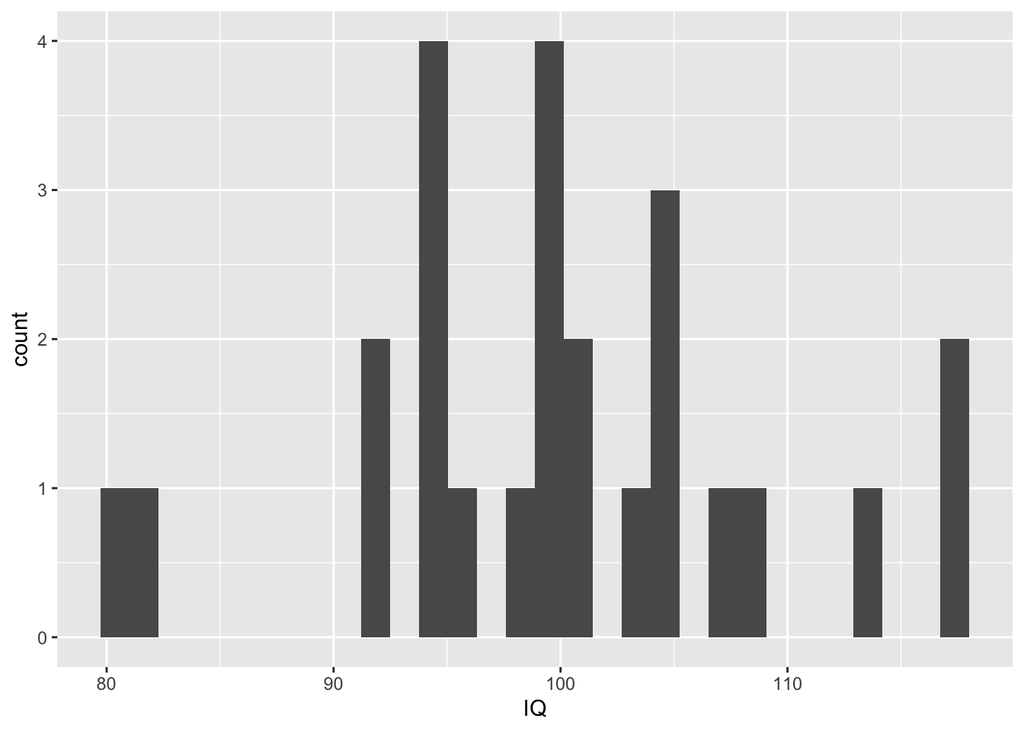

```r
ggplot(mh, aes(IQ)) +
  geom_histogram()
```

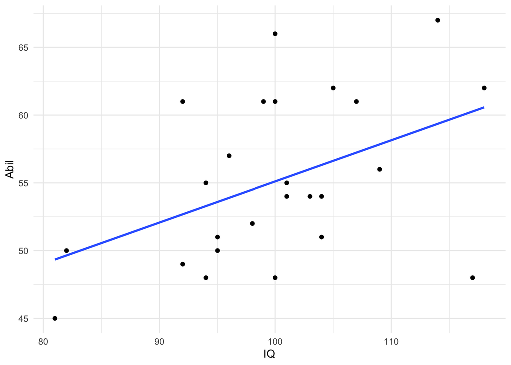

```r
ggplot(mh, aes(x = IQ, y = Abil)) +
  geom_point() +
  geom_smooth(method = "lm", se = FALSE) +
  theme_minimal()
```

```r
results <- cor.test(mh$Abil, mh$IQ, method = "pearson", alternative = "two.sided") %>%
  tidy()

pvalue <- results %>%
  pull(p.value) %>%
  round(3)

df <- results %>%
  pull(parameter)

correlation <- results %>%
  pull(estimate) %>%
  round(2)
```

#### Write up

- A pearson correlation found reading ablility and intelligence to be positively correlated with a medium to strong relationship, (r(23) = 0.45, p = 0.024). As such we can say that our hypothesis is supported and that there appears to be a relationship between reading ability and IQ in that as reading ability increases so does intelligence.

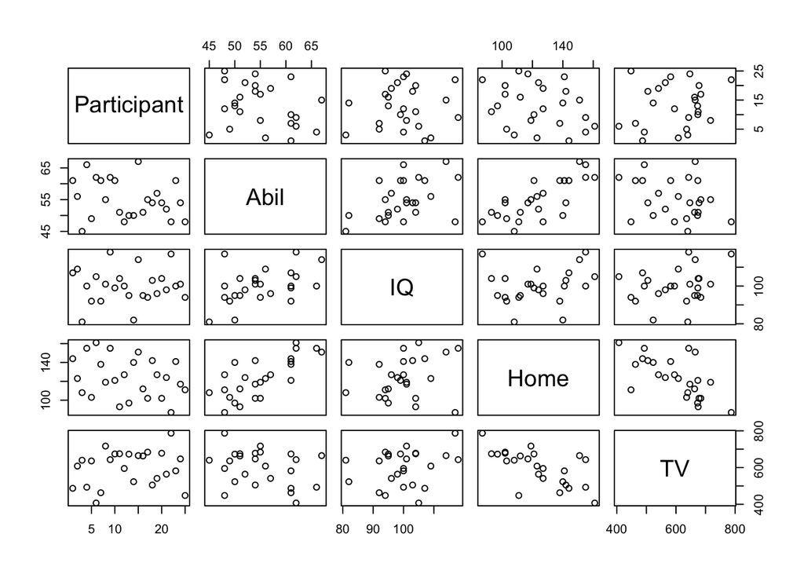

```r
pairs(mh)
```

```r
mh_mx <- as.matrix(mh)
rcorr(mh_mx, type = "pearson")
```

```
##             Participant  Abil   IQ  Home    TV
## Participant        1.00 -0.25 0.04 -0.28  0.17
## Abil              -0.25  1.00 0.45  0.74 -0.29
## IQ                 0.04  0.45 1.00  0.20  0.25
## Home              -0.28  0.74 0.20  1.00 -0.65
## TV                 0.17 -0.29 0.25 -0.65  1.00
##
## n= 25
##
##
## P
##             Participant Abil   IQ     Home   TV
## Participant             0.2348 0.8399 0.1712 0.4265
## Abil        0.2348             0.0236 0.0000 0.1624
## IQ          0.8399      0.0236        0.3337 0.2368
## Home        0.1712      0.0000 0.3337        0.0005
## TV          0.4265      0.1624 0.2368 0.0005
```

```r
vaping <- read_csv("VapingData.csv")
glimpse(vaping)
```

```
## Rows: 166
## Columns: 8
## $ Participant              <dbl> 1, 2, 3, 4, 5, 6, 7, 8, 9, 10, 13, 14, 15, 1…
## $ IAT_BLOCK3_RT            <dbl> 796.80, 630.38, 568.52, 533.65, 773.28, 562.…
## $ IAT_BLOCK3_Acc           <dbl> 0.93, 1.00, 0.97, 0.84, 0.88, 0.94, 0.97, 0.…
## $ IAT_BLOCK5_RT            <dbl> 896.10, 730.87, 733.61, 666.63, 659.70, 807.…
## $ IAT_BLOCK5_Acc           <dbl> 0.93, 0.90, 0.58, 0.94, 0.97, 0.86, 0.71, 0.…
## $ VapingQuestionnaireScore <dbl> 46, 42, 62, 75, 68, 34, 56, 64, NA, NA, 69, …
## $ Sex                      <chr> "Female", "Female", "Male", "Female", "Male"…
## $ Age                      <dbl> 18, 19, 27, 19, 19, 20, 19, 19, 38, 19, 21, …
```

```r
sum(is.na(vaping$IAT_BLOCK5_Acc))
```

```
## [1] 0
```

```r
head(vaping)
```

```
## # A tibble: 6 x 8
##   Participant IAT_BLOCK3_RT IAT_BLOCK3_Acc IAT_BLOCK5_RT IAT_BLOCK5_Acc
##         <dbl>         <dbl>          <dbl>         <dbl>          <dbl>
## 1           1          797.           0.93          896.          0.93
## 2           2          630.           1             731.          0.9
## 3           3          569.           0.97          734.          0.580
## 4           4          534.           0.84          667.          0.94
## 5           5          773.           0.88          660.          0.97
## 6           6          563.           0.94          807.          0.86
## # … with 3 more variables: VapingQuestionnaireScore <dbl>, Sex <chr>, Age <dbl>
```

```r
vaping2 <-  vaping %>%
  filter(IAT_BLOCK3_Acc <= 1 & IAT_BLOCK5_Acc <=1) %>%
  mutate(IAT_average_acc = (IAT_BLOCK3_Acc + IAT_BLOCK5_Acc)/2) %>%
  filter(IAT_average_acc >= .8) %>%
  mutate(IAT_RT = IAT_BLOCK5_RT - IAT_BLOCK3_RT)

length(vaping$IAT_BLOCK3_Acc)
```

```
## [1] 166
```

```r
length(vaping$IAT_BLOCK5_Acc)
```

```
## [1] 166
```

```r
length(vaping2$IAT_BLOCK3_Acc)
```

```
## [1] 157
```

```r
length(vaping2$IAT_BLOCK5_Acc)
```

```
## [1] 157
```

```r
head(vaping2)
```

```
## # A tibble: 6 x 10
##   Participant IAT_BLOCK3_RT IAT_BLOCK3_Acc IAT_BLOCK5_RT IAT_BLOCK5_Acc
##         <dbl>         <dbl>          <dbl>         <dbl>          <dbl>
## 1           1          797.           0.93          896.           0.93
## 2           2          630.           1             731.           0.9
## 3           4          534.           0.84          667.           0.94
## 4           5          773.           0.88          660.           0.97
## 5           6          563.           0.94          807.           0.86
## 6           7          806.           0.97         1113.           0.71
## # … with 5 more variables: VapingQuestionnaireScore <dbl>, Sex <chr>,
## #   Age <dbl>, IAT_average_acc <dbl>, IAT_RT <dbl>
```

```r
descriptives <- vaping2 %>%
  summarise(n = n(),
            mean_IAT_ACC = mean(IAT_average_acc),
            mean_IAT_RT = mean(IAT_RT),
            mean_VPQ = mean(VapingQuestionnaireScore, na.rm = TRUE))
```

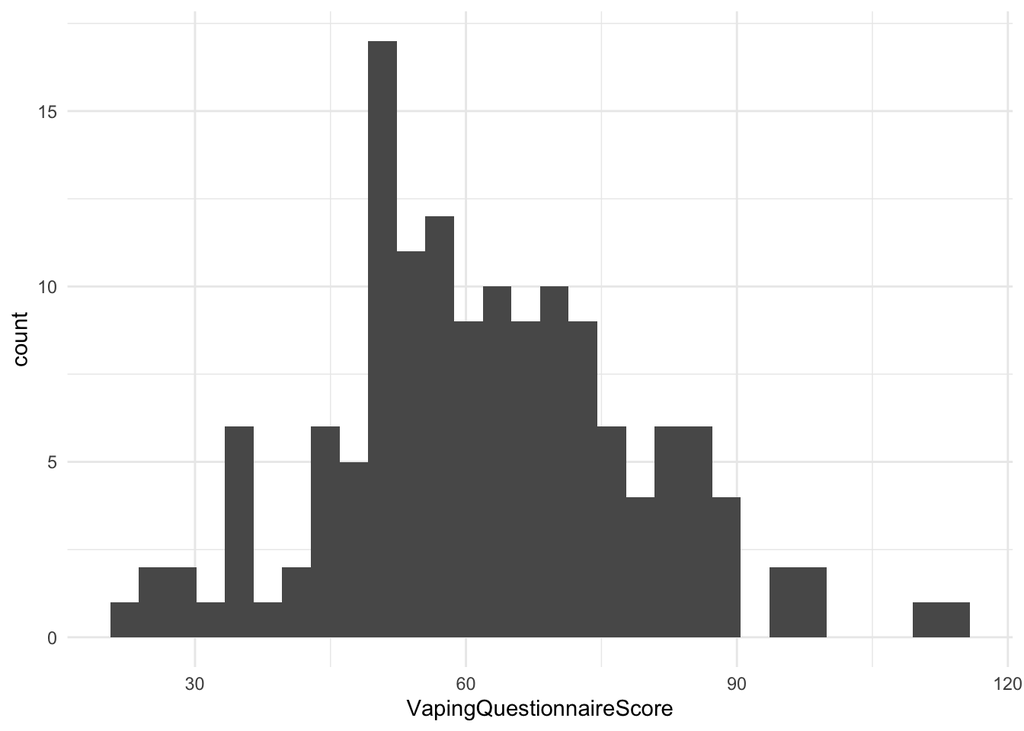

```r
ggplot(vaping2, aes(VapingQuestionnaireScore)) +
  geom_histogram() +
  theme_minimal()
```

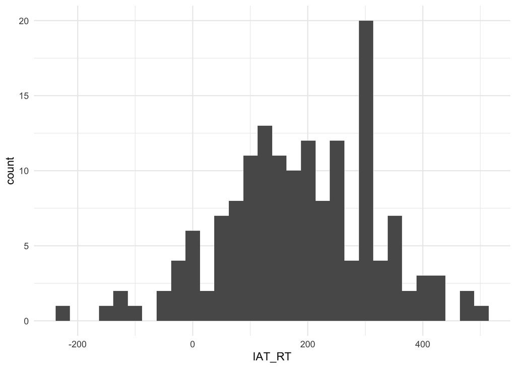

```r
ggplot(vaping2, aes(IAT_RT)) +
  geom_histogram() +
  theme_minimal()
```

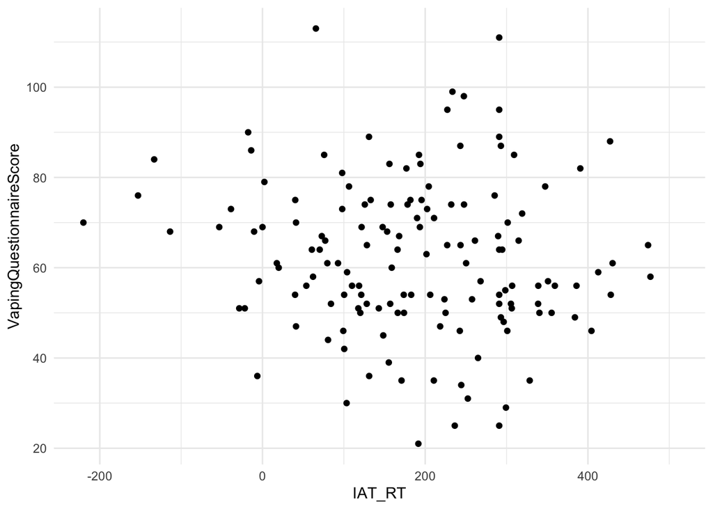

```r
ggplot(vaping2, aes(x = IAT_RT, y = VapingQuestionnaireScore)) +
  geom_point() +
  theme_minimal()
```

```r
vaping3 <- vaping2 %>%
  filter(!is.na(VapingQuestionnaireScore)) %>%
  filter(!is.na(IAT_RT))
```

```r
vap_results <- cor.test(vaping3$VapingQuestionnaireScore,
                        vaping3$IAT_RT,
                        method = "pearson") %>%
  tidy()

correlation <- vap_results %>%
  pull(estimate) %>%
  round(3)

df <- vap_results %>%
  pull(parameter)

pvalue <- vap_results %>%
  pull(p.value) %>%
  round(3)
```

#### Write up

- Testing the hypothesis that there would be a relationship between implicit and explicit vaping, a pearson correlation found no significant relationship between IAT reaction times (implicit attitude) and answers on a Vaping Questionnaire (explicit attitude), r(143) = -0.104, p = 0.212. Overall this suggests that there is no direct relationship between implicit and explicit attitudes when relating to Vaping and as such our hypothesis was not supported; we cannot reject the null hypothesis.